# Math 151AH: HW2

# Problem 1)

```python
import numpy as np

a = np.array([[0.4218,0.6557,0.6787,0.6555],
              [0.9157,0.0357,0.7577,0.1712],
              [0.7922,0.8491,0.7431,0.7060],
              [0.9595,0.9340,0.3922,0.0318]])
c = np.array([0.2769,0.0462,0.0971,0.8235])

def gaussian_elimination(A,b):
    A = A.copy()
    b = b.copy()
    for i in range(A.shape[1]):
        b[i] = b[i] / A[i,i]
        A[i,:] =  A[i,:]/A[i,i]
        if i < A.shape[1]-1:
            for j in range(i+1,A.shape[1]):
                b[j] = b[j] - A[j,i] * b[i]
                A[j,:] -= A[j,i] * A[i,:]
    for i in range(A.shape[1]-2,-1,-1):
        for j in range(i+1,A.shape[1]):
            b[i] = b[i] - A[i,j]*b[j]
            A[i,:] = A[i,:] - A[i,j] * A[j,:]
    return b


x=gaussian_elimination(a,c)
print(f"x = {x}")
```

```
x = [-1.26040472  1.40084283  2.03133593 -2.27103223]
```

# Problem 2)

### Part a)

WTS $Av=\lambda v\Rightarrow\rho(A)v=\rho(\lambda)v$

Suppose $\rho(A)=\sum_{i=0}^m c_iA^i$ for coefficients $c_i$. Then $\rho(A)v=\sum_{i=0}^m c_iA^iv$

Note that $A^iv=\lambda A^{i-1}v = ... = \lambda^{i-1}Av = \lambda^i v$

Thus $\rho(A)v=\sum_{i=0}^m c_i\lambda^iv=v\sum_{i=0}^mc_i\lambda^i=\rho(\lambda)v$

### Part b)

$$ \begin{aligned} \rho(A)&=\rho(P\Lambda P^{-1})\\ &=\sum_{i=0}^mc_i(P\Lambda P^{-1})^i\\ &=\sum_{i=0}^m c_iP\Lambda^i P^{-1} \\ &=P(\sum_{i=0}^mc_i\Lambda^i)P^{-1}\\ &=P\rho(\Lambda)P^{-1} \end{aligned} $$

Since $\Lambda$ is diagonal, $(\Lambda^k)_{i,j}=(\Lambda_{i,j})^k$ and its diagonal entries of $\Lambda$ are the eigenvalues of $A$, therefore $\rho(\Lambda)=\text{diag}(\rho(\lambda_1),...,\rho(\lambda_n))$.

### Part c)

$$ \begin{aligned} e^A&=e^{P\Lambda P^{-1}}\\ &=\sum_{k=1}^\infty\frac1{k!}(P\Lambda P^{-1})^k\\ &=\sum_{k=1}^\infty\frac1{k!}P\Lambda^k P^{-1}\\ &=P(\sum_{k=1}^\infty\frac1{k!}\Lambda^k)P^{-1}\\ &=P e^\Lambda P^{-1} \end{aligned} $$

Since $\Lambda$ is diagonal, $e^\Lambda = \text{diag}(e^{\lambda_1},...,e^{\lambda_n})$ as before in part b.

# Problem 3)

### Part a)

$$ \begin{aligned} \|x+y\|_1 &= \sum_{i=1}^n|x_i+y_i|\\ &\leq\sum_{i=1}^n(|x_i|+|y_i|)\\ &=\sum_{i=1}^n|x_i| + \sum_{i=1}^n|y_i|\\ &=\|x\|_1+\|y\|_1 \end{aligned} $$

### Part b)

$$ \begin{aligned} \|x+y\|_\infty &=\max_i|x_i+y_i|\\ &=|x_I+y_I| &&\text{for some }I\leq n\\ &\leq|x_I|+|y_I|\\ &\leq\max_i|x_i|+\max_i|y_i|\\ &=\|x\|_\infty+\|y\|_\infty \end{aligned} $$

# Problem 4)

### Part a)

For $u(t)=\frac{t^p}p+\frac1q-t$, $$\begin{aligned} \frac{du}{dt}&=t^{p-1}-1=0\Rightarrow t=1\\ \frac{d^2u}{d^t}&=(p-1)t^{p-2}=p-1>0\text{ at }t=1\\ u(1)&=0,u(0)=\frac1q>0 \\ \Rightarrow 1&=\argmin_t u(t)\\ \text{For }t^*=ab^{-\frac qp}\text{,}\\ u(1)&\leq u(t^*)\\ \Rightarrow 0&\leq \frac{a^pb^{-q}}p+\frac1q-ab^{-\frac qp}\\ \Rightarrow 0&\leq\frac{a^p}p + \frac{b^q}{q}-ab^{q-\frac qp}\\ &= \frac{a^p}p + \frac{b^q}{q}-ab^{q(1-\frac1p)}\\ &= \frac{a^p}p + \frac{b^q}{q}-ab^{q\frac1q}\\ &= \frac{a^p}p + \frac{b^q}{q}-ab\\ \Rightarrow ab&\leq \frac{a^p}p +\frac{b^q}q \end{aligned}$$

### Part b)

$$\begin{aligned} \frac1{\|x\|_p\|y\|_q}\sum_{k=1}^n|x_ky_k|&=\sum_{k=1}^n\frac{|x_k|}{\|x\|_p}\frac{|y_k|}{\|y\|_q}\\ &\leq \sum_{k=1}^n(\frac1p\frac{|x_k|^p}{\|x\|_p^p}+\frac1q\frac{|y_k|^q}{\|y\|_q^q})\\ &=\frac1p\|x\|_p^{-p}\sum_{k=1}^n|x_k|^p+\frac1q\|y\|_q^{-q}\sum_{k=1}^n|y_k|^q\\ &=\frac1p\|x\|_p^{-p}\|x\|_p^p+\frac1q\|y\|_q^{-q}\|y\|_q^q\\ &=\frac1p+\frac1q\\ &=1\\ \Rightarrow \sum_{k=1}^n|x_ky_k|&\leq \|x\|_p\|y\|_q \end{aligned}$$

### Part c)

$$\begin{aligned} \|x+y\|_p^p&=\sum_{i=1}^n|x_i+y_i|^{p-1}|x_i+y_i|\\ &\leq \sum_{i=1}^n|x_i||x_i+y_i|^{p-1}+\sum_{i=1}^n|y_i||x_i+y_i|^{p-1}\\ &\leq \|x\|_p(\sum_{i=1}^n(x_i+y_i)^{q(p-1)})^\frac 1q+\|y\|_p(\sum_{i=1}^n(x_i+y_i)^{q(p-1)})^\frac 1q\\ &=(\|x\|_p+\|y\|_p)(\sum_{i=1}^n(x_i+y_i)^p)^\frac 1q\\ &=(\|x\|_p+\|y\|_p)(\sum_{i=1}^n(x_i+y_i)^p)^{1-\frac 1p}\\ \Rightarrow \|x+y\|_p&\leq (\|x\|_p+\|y\|_p)\frac{\sum_{i=1}^n(x_i+y_i)^p}{\|x+y\|_p^p}\\ &=(\|x\|_p+\|y\|_p)(\sum_{i=1}^n(x_i+y_i)^p)^{1-1}\\ &=\|x\|_p+\|y\|_p \end{aligned}$$

# Problem 5)

### Part a)

$v^Tw=\sum_{k=1}^nv_kw_k\leq\sum_{k=1}^n|v_kw_k|\leq\|v\|_p\|w\|_q\leq\|v\|_p$

## Part b)

We are looking for $w^*$ s.t. the above inequality holds as an equality. The inequality comes from two sources: the first is $v_kw_k\leq|v_kw_k|$, which holds equal when sign $(v_k)=$ sign $(w_k)$. The second is Hölder's inequality, which holds as an equality when Young's inequality in turn holds as an equality. This occurs when $ab^{-\frac qp}=1$. Translating to the current problem, this condition becomes $$ \frac{|v_k|}{\|v\|_p}(\frac{|w_k|}{\|w\|_q})^{-\frac qp}=1 $$ Assuming for now that $\|w\|_q=1$, this gives that $$ |w_k|=(\frac{|v_k|}{\|v\|_p})^\frac pq $$ The first condition dictates that sign $(w_k)=$ sign $(v_k)$.

## Part c)

Part a shows that for the region that we are maximizing $v^Tw$ over, the $v^Tw\leq\|v\|_p$. Therefore the maximized value must also be less than or equal to $\|v\|_p$. Part b shows that there exists $w$ such that the value $\|v\|_p$ is attained. Since all greater values have been shown to be unattainable, we can conclude that $\|v\|_p$ is the maximum.

# Problem 6)

Let $p(x)=\sum_{i=0}^nc_ix^i \in P_n$ for $c_i\in\mathbb{R}$ be represented by coordinates $c=(c_0,...c_n)\in\mathbb{R}^n$ with respect to the given basis.

Then $\frac d{dx}p(x)=\sum_{i=0}^nic_ix^{i-1}=\sum_{i=0}^{n-1}(i+1)c_{i+1}x^i$

can be represented by $\hat c=(\hat c_0,...\hat c_n)$ where $\hat c_i=(i+1)c_{i+1}$ for $i<n$ and $\hat c_n=0$.

The derivative operator is linear: let $p,q\in P_n$. Then for $\alpha,\beta\in\mathbb{R}$,

$$\begin{aligned} \frac d{dx}(\alpha p(x)+\beta q(x)) &= \frac d{dx}(\alpha\sum_{i=0}^np_ix^i + \beta\sum_{i=0}^nq_ix^i)\\ &=\alpha\sum_{i=0}^nip_ix^{i-1} + \beta\sum_{i=0}^niq_ix^{i-1}\\ &=\sum_{i=0}^n(\alpha p_i+\beta q_i)ix^{i-1}\\ &=\sum_{i=0}^{n-1}(\alpha p_{i+1}+\beta q_{i+1})(i+1)x^i\\ \end{aligned}$$

has coordinates with respect to $\{x^i\}_{0\leq i\leq n}$ and is thus in $P_n$. Furthermore, the derivative operator can be represented by matrix $A\in\mathbb{R}^{n\times n}$ where $A_{i,i+1}=i$ for $i<n+1$ and all other entries are 0. $A$ has no eigenvalues since every nonzero polynomial loses a degree under differentiation: the "highest" nonzero coordinate becomes zero.

# Problem 7)

### Part a)

$$\begin{aligned} \|D\|_\infty&=\sup_{\|v\|_1=1}\|Dv\|_\infty\\ &=\max_v(\max_i\{D_{i,i}v_i\}) \text{ s.t. }\sum_i|v_i|=1\\ |v_i|&\leq 1 \Rightarrow D_{i,i}v_i\leq|D_{i,i}v_i|\leq |D_{i,i}|\\ D_{i,i}v_i&=|D_{i,i}| \text{ for } v_i=\text{sign}(D_i),v_j=0 \forall j\not=i\\ &\text{so }D_{i,i}v_i\text{ is maximized with }v\text{ s.t. all weight is on }D_{i,i}.\\ &\text{This makes the maximization problem a choice of }i.\\ \Rightarrow \|D\|_\infty&= \max_v\{\max_i\{D_{i,i}v_i\}\}\\ &=\max_i|D_{i,i}| \end{aligned}$$

### Part b)

$$\begin{aligned} \|U\|_2&=\sup_{v\not=0}\frac{\|Qv\|_2}{\|v\|_2}\\ &=\sup_{v\not=0}(\frac{<Qv,Qv>}{<v,v>})^{\frac12}\\ &=\sup_{v\not=0}(\frac{<v,Q^*Qv>}{<v,v>})^\frac12\\ &=\sup_{v\not=0}(\frac{<v,v>}{<v,v>})^\frac12\\ &=1 \end{aligned}$$

### Part c)

By Schur decomposition there exists a unitary matrix $U$ s.t. $A=U^*TU$ for upper triangular $T$. $$\begin{aligned} UAU^*&=T\\ \Rightarrow(UAU^*)^*&=T^*\\ \Rightarrow UA^*U^*&=T^*\\ \Rightarrow UAU^*&=T^*\\ \Rightarrow T&=T^* \end{aligned}$$

Since $T$ is upper triangular, this implies that $T$ must be diagonal.

# Problem 8)

```python
def diagonal(A):
    n = len(A)
    D = np.zeros([n,n])
    D[np.diag_indices(n)] = A[np.diag_indices(n)]
    return D

def error(x):
    return ((x - np.array([1,2,3,4]))**2).sum()**0.5

def Jacobi(A, b, N=100):
    n = len(a)
    A2 = diagonal(A)
    A2inv = np.zeros([n,n])
    A2inv[np.diag_indices(n)] = np.reciprocal(A2[np.diag_indices(n)])
    A1 = A - A2
    x = [np.zeros(n)]
    count = 0
    while error(x[-1]) > 10**(-8) and count < N:
        x.append(A2inv.dot(b-A1.dot(x[-1])))
        count += 1
    return x

a = np.array([[2.4117,0.6557,0.6787,0.6555],
              [0.9157,1.8804,0.7577,0.1712],
              [0.7922,0.8491,3.0905,0.7060],
              [0.9595,0.9340,0.3922,2.3175]])
c = np.array([8.3813,7.6345,14.5862,13.2743])

X = Jacobi(a,c, N=200)
eJ = [np.log(error(x)) for x in X]
```

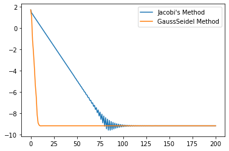

```python
def GaussSeidel(A, b, N=100):
    n = len(a)
    x = [np.zeros(n)]
    count = 0
    while error(x[-1]) > 10**(-8) and count < N:
        xk = np.zeros(n)
        xk1 = x[-1]
        for i in range(n):
            s1 = sum([A[i,j]*xk[j] for j in range(i)])
            s2 = sum([A[i,j]*xk1[j] for j in range(i+1,n)])
            xk[i] = 1/A[i,i]*(b[i] - s1 - s2)
        x.append(xk)
        count += 1
    return x

X = GaussSeidel(a,c,N=200)
eG = [np.log(error(x)) for x in X]

import matplotlib.pyplot as plt
plt.plot(range(len(eJ)), eJ, label="Jacobi's Method")
plt.plot(range(len(eG)), eG, label="GaussSeidel Method")
plt.legend()
plt.show()
```